# Bar Charts of Mean Price

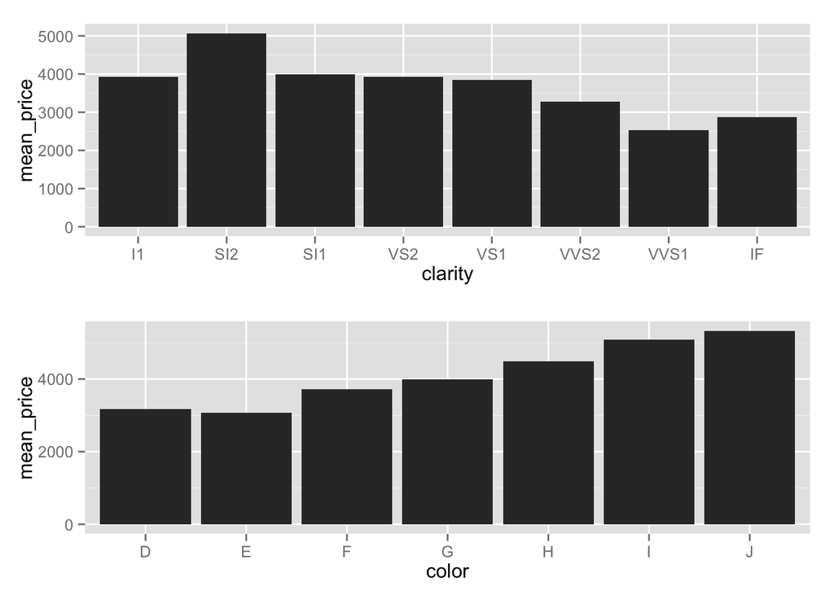

```r
diamonds_by_clarity <- group_by(diamonds, clarity)
diamonds_mp_by_clarity <- summarise(diamonds_by_clarity, mean_price = mean(price))

diamonds_by_color <- group_by(diamonds, color)
diamonds_mp_by_color <- summarise(diamonds_by_color, mean_price = mean(price))

p1 <- ggplot(aes(x=clarity,y=mean_price),data=diamonds_mp_by_clarity)+
  geom_bar(stat="identity")
p2 <- ggplot(aes(x=color,y=mean_price),data=diamonds_mp_by_color)+
  geom_bar(stat="identity")
grid.arrange(p1,p2,ncol=1)
```

We think something odd is going here. These trends seem to go against our intuition.

Mean price tends to decrease as clarity improves. The same can be said for color.

We encourage you to look into the mean price across cut. diamonds_by_color <- group_by(diamonds, color) diamonds_mp_by_color <- summarise(diamonds_by_color, mean_price = mean(price))

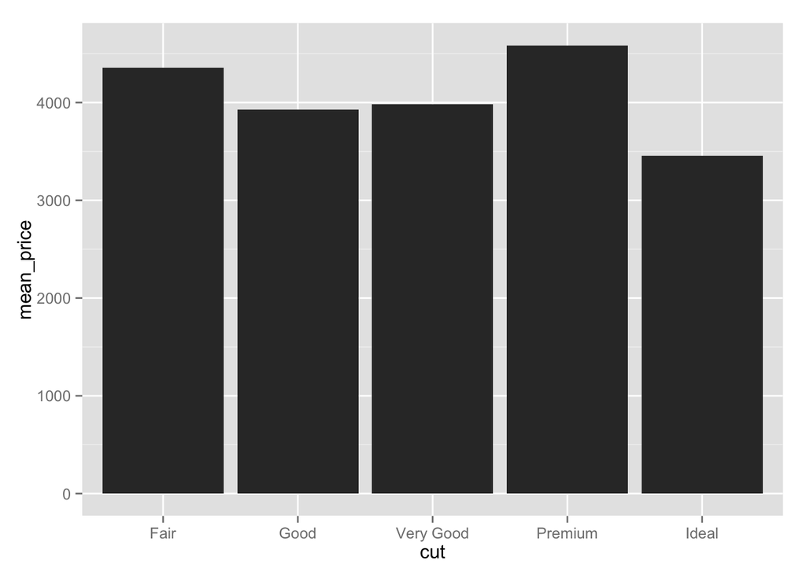

```r
diamonds_by_cut <- group_by(diamonds, cut)
diamonds_mp_by_cut <- summarise(diamonds_by_cut, mean_price = mean(price))

ggplot(aes(x=cut,y=mean_price),data=diamonds_mp_by_cut)+
  geom_bar(stat="identity")
```

#Gapminder Revisited

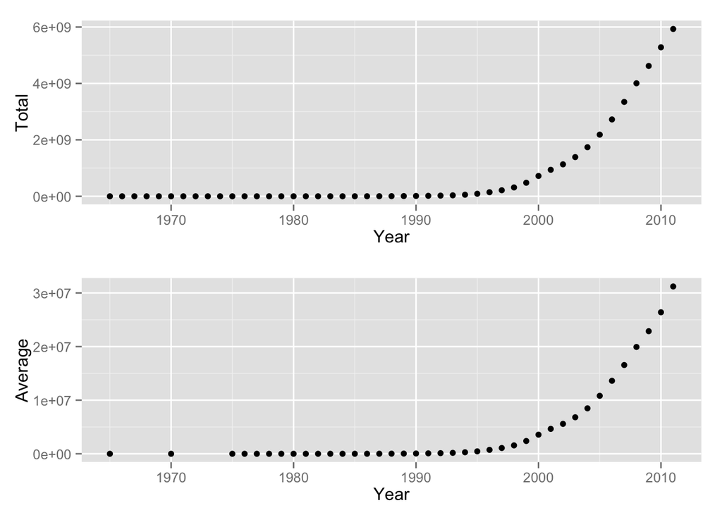

```r
cp <- read.csv("cell phone total.csv", header = T, row.names=1)
Total <- colSums(cp, na.rm=T)
Average <- colMeans(cp,na.rm = T)
df_y <- as.data.frame(cbind(Total,Average))
df_y$Year <- as.numeric(substr(rownames(df_y),start=2,stop=5))
p1 <- ggplot(aes(x=Year,y=Total),data=df_y)+ geom_point()+
  xlim(1965,2011)
p2 <- ggplot(aes(x=Year,y=Average),data=df_y)+geom_point()+
  xlim(1965,2011)

grid.arrange(p1,p2,ncol=1)
```

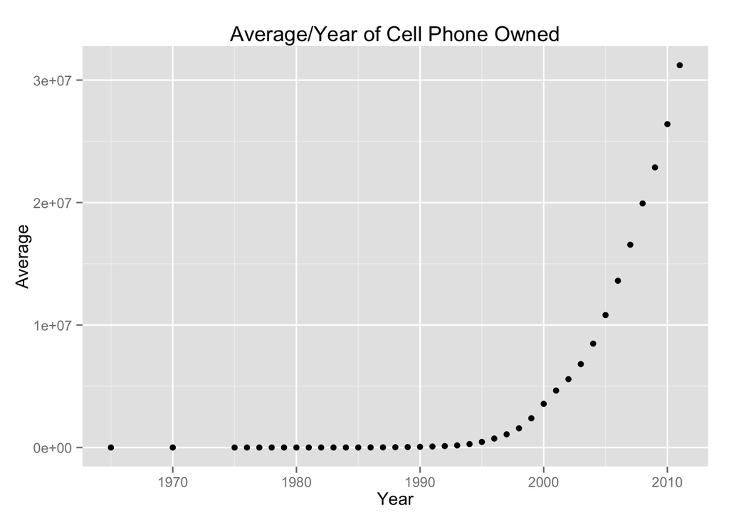

```r
cp <- read.csv("cell phone total.csv", header = T, row.names=1)
df_y <- as.data.frame(colMeans(cp,na.rm = T))
df_y$Year <- as.numeric(substr(rownames(df_y),start=2,stop=5))
ggplot(aes(x=Year,y=Average),data=df_y)+geom_point()+
  xlim(1965,2011)+
  ggtitle('Average/Year of Cell Phone Owned')+
  ggsave('avgpycpplot.jpg')
```